# HR

Mike Pheasant

01/05/2017

## Load and Summarize Data

Derive a location (Brisbane, San Francisco or London) from the employee role: * 90% of IT staff in Brisbane (5% in each other location) * 90% sales in San Francisco (5% in each other location) * 90% other categories in London (5% in each other location)

```r
location <- function(role) {
  prob=switch(as.character(role),
              IT=c(0.9, 0.05, 0.05),
              sales=c(0.05, 0.9, 0.05),
              c(0.05, 0.05, 0.9)
  )
  sample(c('Brisbane','San Francisco','London'), 1, rep=TRUE, prob=prob)
}
```

Load raw data (from https://www.kaggle.com/ludobenistant/hr-analytics), add factors, save, and summarise.

```r
HR <- read_csv("HR_comma_sep.csv", col_types=cols(
  satisfaction_level = col_double(),
  last_evaluation = col_double(),
  number_project = col_integer(),
  average_montly_hours = col_integer(),
  time_spend_company = col_integer(),
  Work_accident = col_integer(),
  left = col_integer(),
  promotion_last_5years = col_integer(),
  sales = col_character(),
  salary = col_character()
))

# pch=c(15,16,17) ,

HR$salary <- factor(HR$salary, levels=c("low", "medium", "high"), ordered=TRUE)
HR$sales <- factor(HR$sales)
HR$location <- factor(sapply(HR$sales, location))

HR$Work_accident_ <- factor(HR$Work_accident == 1)
HR$promotion_last_5years_ <- factor(HR$promotion_last_5years == 1)
HR$left_ <- factor(HR$left==1)

write_csv(HR, "HR.csv")

summary(HR)
```

```
##  satisfaction_level last_evaluation  number_project  average_montly_hours
##  Min.   :0.0900     Min.   :0.3600   Min.   :2.000   Min.   : 96.0
##  1st Qu.:0.4400     1st Qu.:0.5600   1st Qu.:3.000   1st Qu.:156.0
##  Median :0.6400     Median :0.7200   Median :4.000   Median :200.0
##  Mean   :0.6128     Mean   :0.7161   Mean   :3.803   Mean   :201.1
##  3rd Qu.:0.8200     3rd Qu.:0.8700   3rd Qu.:5.000   3rd Qu.:245.0
##  Max.   :1.0000     Max.   :1.0000   Max.   :7.000   Max.   :310.0
##
##  time_spend_company Work_accident         left
##  Min.   : 2.000     Min.   :0.0000   Min.   :0.0000
##  1st Qu.: 3.000     1st Qu.:0.0000   1st Qu.:0.0000
##  Median : 3.000     Median :0.0000   Median :0.0000
##  Mean   : 3.498     Mean   :0.1446   Mean   :0.2381
##  3rd Qu.: 4.000     3rd Qu.:0.0000   3rd Qu.:0.0000
##  Max.   :10.000     Max.   :1.0000   Max.   :1.0000
##
##  promotion_last_5years         sales         salary
##  Min.   :0.00000       sales      :4140   low   :7316
##  1st Qu.:0.00000       technical  :2720   medium:6446
##  Median :0.00000       support    :2229   high  :1237
##  Mean   :0.02127       IT         :1227
##  3rd Qu.:0.00000       product_mng: 902
##  Max.   :1.00000       marketing  : 858
##                        (Other)    :2923
##           location    Work_accident_ promotion_last_5years_   left_
##  Brisbane     :1861   FALSE:12830    FALSE:14680            FALSE:11428
##  London       :8905   TRUE : 2169    TRUE :  319            TRUE : 3571
##  San Francisco:4233
##
##
##
##
```

## Exploratory Data Analysis

### Numeric Correlations

Leaving is negatively correlated with:

- satisfaction level (-0.39)
- having a work accident (-0.15)
- and less so with a promotion in the last 5 years (-0.06)

Leaving is positively correlated with:

- the time spent with the company (0.14)
- and less so with average hours worked per month (0.07)

In addition:

- satisfaction level is correlated with last evaluation (0.11), and negatively with number of projects (-0.14) and time spent with company (-0.10)
- last evaluation is positively correlated with number of projects (0.35), average monthly hours (0.34) and time spent with company (0.13)

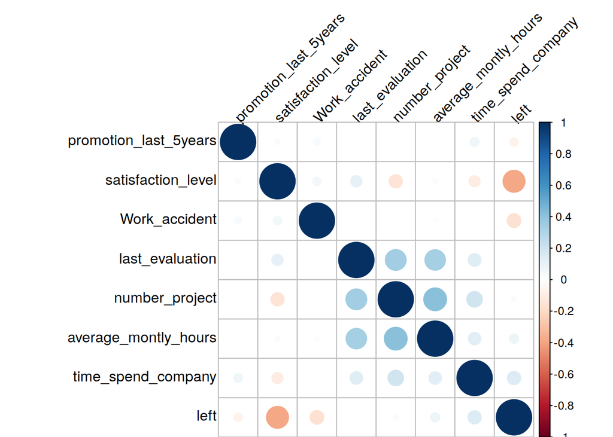

```r
M <- cor(HR[1:8])
corrplot(M, method = 'circle', order ="hclust",
         tl.col="black", tl.cex = 1, tl.offset = 0.1, tl.srt = 45)
```

### Career advancement

Many people leaving have been with the company at least 4 years but have not had a promotion in the last 5 years, despite working long hours.

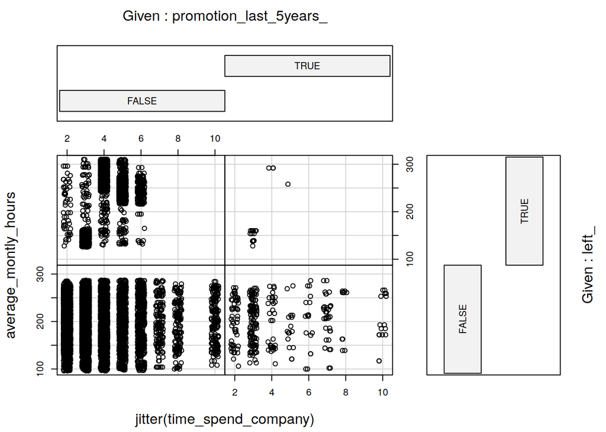

```r
with(HR, coplot(average_montly_hours ~ jitter(time_spend_company) |
                promotion_last_5years_ + left_))
```

These unpromoted, long-term workers who leave are receiving the highest evaluations.

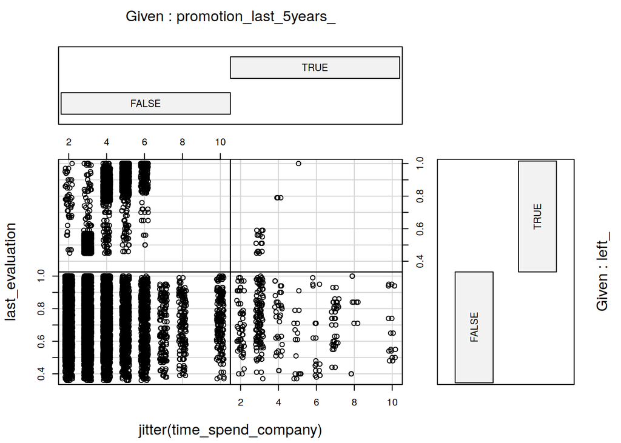

```r
with(HR, coplot(last_evaluation ~ jitter(time_spend_company) |
                promotion_last_5years_ + left_))
```

These unpromoted, long-term workers who leave are also reporting high levels of satisfaction with the company.

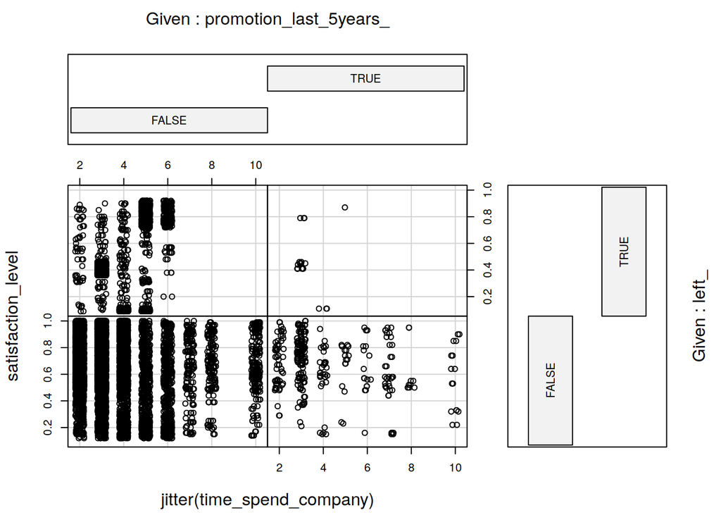

```r
with(HR, coplot(satisfaction_level ~ jitter(time_spend_company) |
                promotion_last_5years_ + left_))
```

Of the unpromoted workers putting in long hours who are leaving, some report the lowest levels of satisfaction, but more report very high levels of satisfaction.

The ones who are working the fewest hours report fairly low satisfaction.

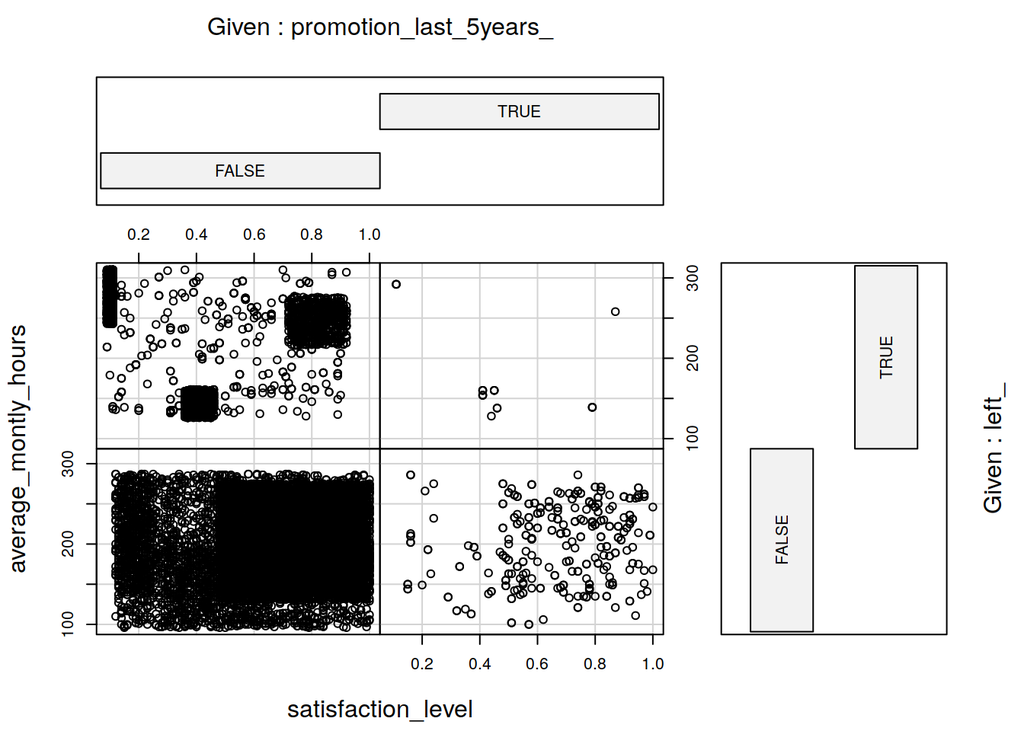

```r
with(HR, coplot(average_montly_hours ~ satisfaction_level |
                promotion_last_5years_ + left_))
```

The staff on the largest number of projects and who put in the longest hours, with no promotion in 5 years, tend to leave.

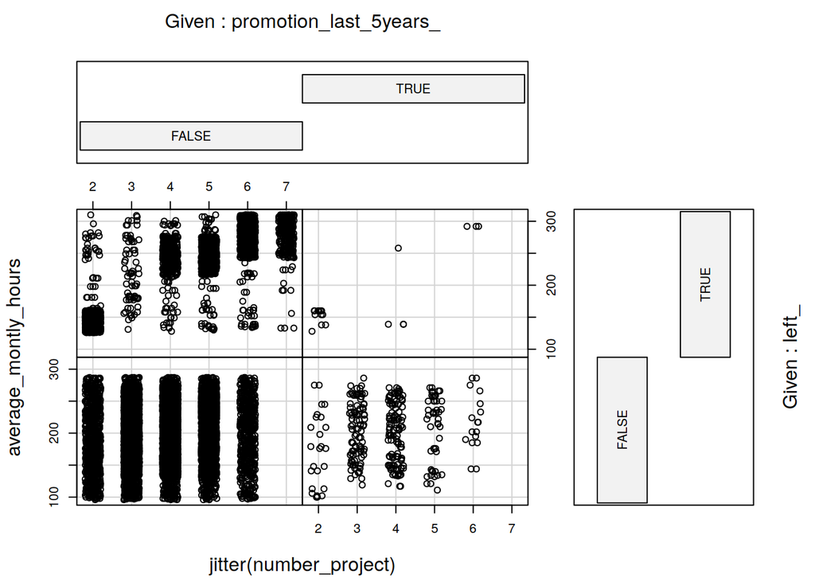

```r
with(HR, coplot(average_montly_hours ~ jitter(number_project) |
                promotion_last_5years_ + left_))
```

Of the unpromoted workers who left, many had both high evaluations and high levels of satisfaction.

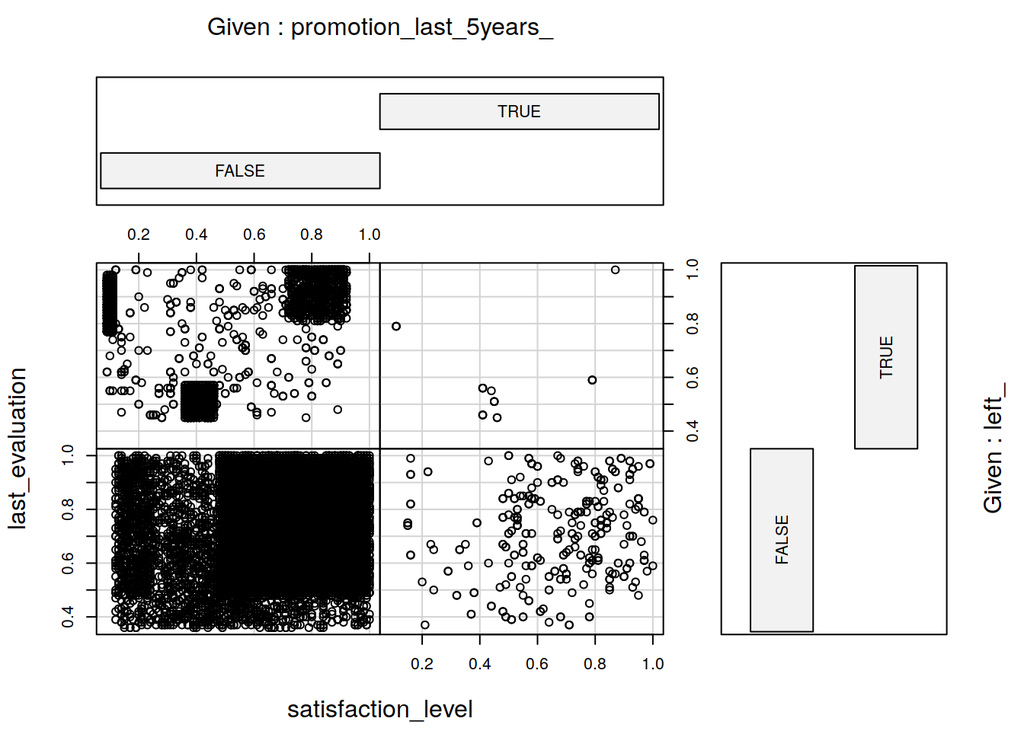

```r
with(HR, coplot(last_evaluation ~ satisfaction_level |
                promotion_last_5years_ + left_))
```

### Pairwise Scatter Plots and Distributions for Staying vs Leaving Staff

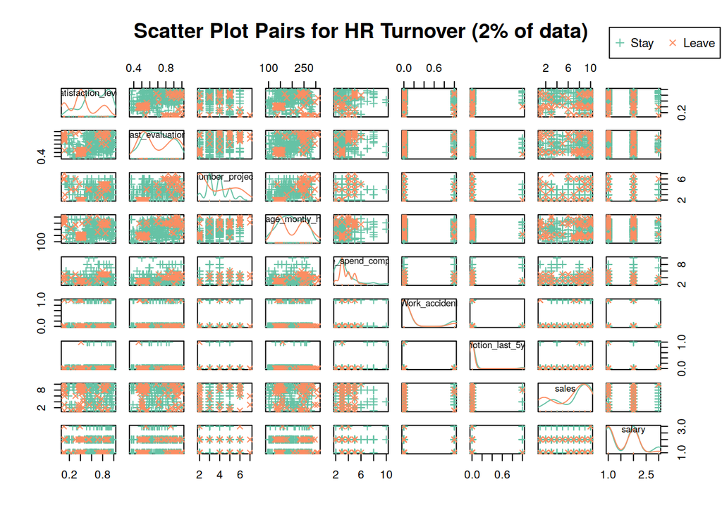

```r
# plot.new()
# png(filename="/Users/mike/play/HR-kaggle/hr-scatter.png", res=300, width = 3000, height = 3000)
my_colors <- brewer.pal(3, "Set2")
samp.sz <- 300
pct <- round(100*samp.sz/nrow(HR))
data <- HR[sample(nrow(HR), samp.sz),]
scatterplotMatrix(~satisfaction_level+last_evaluation+number_project+average_montly_hours+time_spend_company+Work_accident+promotion_last_5years+sales+salary|left, data=data, reg.line="", smoother="", col=my_colors , smoother.args=list(col="grey") , pch=c(3,4), legend.plot=FALSE, main=paste("Scatter Plot Pairs for HR Turnover (",pct,"% of data)", sep=""))
par(xpd=TRUE, cex=0.7)
legend(x=0.93, y=1.16, c("Stay", "Leave"), col=my_colors, pch=c(3,4), horiz=TRUE)
```

```r
#dev.off()
```